# Most Impactful Weather Events on Health and Economy in the United States between 1950 and 2011

## Synopsis

In this analysis, the NOAA storm database is used to examine and rank storms in terms of population health hazard and economic consequences from 1950 to 2011 in the United States.

Property and crop damage data are derived from the original data and their scaling factor.

Event types are mapped to the correct set using REGEX and the amatch function.

From the bar charts of total fatalities, injuries, and total and average property and crop damage, we draw the following conclusions:

- Tornadoes cause the highest number of fatalities and injuries.
- Floods are the greatest cause of property damage followed by hurricanes and tornadoes, although the most damaging on average per event are hurricanes and Storm Surge/Tide.
- Drought, followed by floods and hurricanes are the cause of the greatest damage to crops, although, again, the most damaging on average per event are hurricanes.

## Data Processing

Load libraries and delete variables

```r
library(plyr)
library(dplyr)
library(data.table)
```

```r
library(chron)
# library(lattice)
library(ggplot2)
library(gridExtra)
library(stringdist)
library(stringi)
# library(lubridate)
rm(list=ls())
```

Download file to local “data” folder

```r
# Create data folder if it does not exist
if (!file.exists("data")) {
        dir.create("data")
}
# Download file to local "data" folder if not exists if it does not exist
if (!file.exists("./data/StormData.csv.bz2")) {
        url <- "https://d396qusza40orc.cloudfront.net/repdata%2Fdata%2FStormData.csv.bz2"
        fileUrl <- url
        download.file(fileUrl, destfile = "./data/StormData.csv.bz2",
                      method = "curl")
        dateDownloaded <- date()
        dateDownloaded
}
```

The “df” data frame is created with fread and the data structure and type of each variable is checked.

```r
# library(R.utils)
# system.time(csv_ <- bunzip2("data/StormData.csv.bz2", remove = FALSE))
# time elapsed 10.585
# system.time(bunzip2("data/StormData.csv.bz2", "xxx.csv", remove = FALSE, skip = TRUE))
# time elapsed 5.766
# system.time(dataset <- fread("xxx.csv"))
# time elapsed 31.087
# system.time(dataset <- read.csv("xxx.csv"))

# time elapsed 11.930
# system.time(df <- fread("./data/StormData.csv.bz2"))

# option 1: bunzip2 + fread = 10.585 + 11.930 = 22.515
# option 2: bunzip2 + read.csv = 10.585 + 31.087 = 41.672
# option 3: fread: 11.930
# fastest option: option 3 fread
# Create a "Data Frame" with "fread"
# Only the variables to be used in the analysis are selected.
df <- fread("./data/StormData.csv.bz2", select = c("EVTYPE", "FATALITIES", "INJURIES", "PROPDMG", "PROPDMGEXP", "CROPDMG", "CROPDMGEXP"))
# head(df)
str(df)
```

```
## Classes 'data.table' and 'data.frame':   902297 obs. of  7 variables:
##  $ EVTYPE    : chr  "TORNADO" "TORNADO" "TORNADO" "TORNADO" ...
##  $ FATALITIES: num  0 0 0 0 0 0 0 0 1 0 ...
##  $ INJURIES  : num  15 0 2 2 2 6 1 0 14 0 ...
##  $ PROPDMG   : num  25 2.5 25 2.5 2.5 2.5 2.5 2.5 25 25 ...
##  $ PROPDMGEXP: chr  "K" "K" "K" "K" ...
##  $ CROPDMG   : num  0 0 0 0 0 0 0 0 0 0 ...
##  $ CROPDMGEXP: chr  "" "" "" "" ...
##  - attr(*, ".internal.selfref")=<externalptr>
```

```r
# summary(df)
dim(df)
```

```
## [1] 902297      7
```

There are 902297 records in 7 selected variables that match the expected values.

The ‘CROPDMGEXP’ is the exponent values for ‘CROPDMG’ (crop damage).

```r
unique(df$CROPDMGEXP)
```

```
## [1] ""  "M" "K" "m" "B" "?" "0" "k" "2"
```

In the same way, ‘PROPDMGEXP’ is the exponent values for ‘PROPDMG’ (property damage).

```r
unique(df$PROPDMGEXP)
```

```
##  [1] "K" "M" ""  "B" "m" "+" "0" "5" "6" "?" "4" "2" "3" "h" "7" "H" "-" "1" "8"
```

We convert the characters to lower case.

```r
df$CROPDMGEXP <- tolower(df$CROPDMGEXP)
unique(df$CROPDMGEXP)
```

```
## [1] ""  "m" "k" "b" "?" "0" "2"
```

```r
df$PROPDMGEXP <- tolower(df$PROPDMGEXP)
unique(df$PROPDMGEXP)
```

```
##  [1] "k" "m" ""  "b" "+" "0" "5" "6" "?" "4" "2" "3" "h" "7" "-" "1" "8"
```

The types of exponents of CROPDMGEXP and PROPDMGEXP are replaced by numerical exponents in order to multiply them by the corresponding attribute. [^1]

```r
# We replace the letters b = 10^9, m = 10^6, k = 10^6, h = 10^2.
# The numbers are replaced by 10^The number.
# The symbols "-", "+" and "?" are replaced by 0.
# They are converted to numeric type.

old <- c("k", "m", "",  "b", "+", "0", "5", "6", "?", "4", "2", "3", "h", "7",
         "-", "1", "8")
new <- c(10^3, 10^6, 0, 10^9, 1, 0, 10^5, 10^6, 0, 10^4, 10^2, 10^3, 10^2, 10^7,
         0, 10, 10^8)
df$PROPDMGEXP <- as.numeric(mapvalues(df$PROPDMGEXP, from=old, to=new))
unique(df$PROPDMGEXP)
```

```
##  [1] 1e+03 1e+06 0e+00 1e+09 1e+00 1e+05 1e+04 1e+02 1e+07 1e+01 1e+08
```

```r
old <- c("", "m", "k", "b", "?", "0", "2")
new <- c(0, 10^6, 10^3, 10^9, 0, 0, 10^2)
df$CROPDMGEXP <- as.numeric(mapvalues(df$CROPDMGEXP, from=old, to=new))
unique(df$CROPDMGEXP)
```

```
## [1] 0e+00 1e+06 1e+03 1e+09 1e+02
```

prop_damage and crop_damage are calculated from PROPDMG * PROPDMGEXP and CROPDMG * CROPDMGEXP.

```r
df$prop_damage <- df$PROPDMG * df$PROPDMGEXP
df$crop_damage <- df$CROPDMG * df$CROPDMGEXP
```

The “evtype” field should have a maximum of 48 distinct values. However, it has 985 distinct values due to erroneous mappings.

```r
length(unique(df$EVTYPE))
```

```
## [1] 985
```

In order to map correctly, we performed different steps:

```r
df$EVTYPE <- tolower(df$EVTYPE)
df$EVTYPE <- stri_trim_left(df$EVTYPE)

df$EVTYPE <- sub("tstm|tunderstorm|thuderstorm", "thunderstorm", df$EVTYPE)
df$EVTYPE <- sub("flooding|floods", "flood", df$EVTYPE)
df$EVTYPE <- sub("winds", "wind", df$EVTYPE)
df$EVTYPE <- sub("hvy", "heavy", df$EVTYPE)


df$EVTYPE <- ifelse(grepl("^thun", df$EVTYPE), "thunderstorm wind", df$EVTYPE)
df$EVTYPE <- ifelse(grepl("torn", df$EVTYPE), "tornado", df$EVTYPE)
df$EVTYPE <- ifelse(grepl("hurr", df$EVTYPE) | grepl("typh", df$EVTYPE),
                    "hurricane (typhoon)", df$EVTYPE)
df$EVTYPE <- ifelse(grepl("tropical storm", df$EVTYPE), "tropical storm", df$EVTYPE)
df$EVTYPE <- ifelse(grepl("light\\S", df$EVTYPE), "lightning", df$EVTYPE)
df$EVTYPE <- ifelse(grepl("hail", df$EVTYPE) & !grepl("marine", df$EVTYPE),
                    "hail", df$EVTYPE)
df$EVTYPE <- ifelse(grepl("flash flood", df$EVTYPE), "flash flood", df$EVTYPE)
df$EVTYPE <- ifelse(grepl("flood", df$EVTYPE) & grepl("coas", df$EVTYPE),
                    "coastal flood", df$EVTYPE)
df$EVTYPE <- ifelse(grepl("flood", df$EVTYPE) & grepl("lake", df$EVTYPE),
                    "lakeshore flood", df$EVTYPE)
df$EVTYPE <- ifelse(grepl("flood", df$EVTYPE) & !grepl("lake", df$EVTYPE) &
                    !grepl("coast", df$EVTYPE) & !grepl("flash", df$EVTYPE),
                    "flood", df$EVTYPE)
df$EVTYPE <- ifelse(grepl("flash", df$EVTYPE), "flash flood", df$EVTYPE)
df$EVTYPE <- ifelse(grepl("volcan", df$EVTYPE), "volcanic ash", df$EVTYPE)
df$EVTYPE <- ifelse(grepl("thund", df$EVTYPE) & !grepl("marin", df$EVTYPE),
                    "thunderstorm wind", df$EVTYPE)
df$EVTYPE <- ifelse(grepl("snow", df$EVTYPE) & grepl("lake", df$EVTYPE),
                    "lake-effect snow", df$EVTYPE)
df$EVTYPE <- ifelse(grepl("snow", df$EVTYPE) & !grepl("lake", df$EVTYPE),
                    "heavy snow", df$EVTYPE)
df$EVTYPE <- ifelse(grepl("high wind", df$EVTYPE) & !grepl("marin", df$EVTYPE),
                    "high wind", df$EVTYPE)
df$EVTYPE <- ifelse(grepl("rain", df$EVTYPE), "heavy rain", df$EVTYPE)
df$EVTYPE <- ifelse(grepl("chill", df$EVTYPE) & grepl("extre", df$EVTYPE),
                    "extreme cold/wind chill", df$EVTYPE)
df$EVTYPE <- ifelse(grepl("chill", df$EVTYPE) & !grepl("extre", df$EVTYPE),
                    "cold/wind chill", df$EVTYPE)
df$EVTYPE <- ifelse(grepl("heat", df$EVTYPE) & grepl("ex", df$EVTYPE),
                    "excessive heat", df$EVTYPE)
df$EVTYPE <- ifelse(grepl("heat", df$EVTYPE) & !grepl("ex", df$EVTYPE),
                    "heat", df$EVTYPE)
df$EVTYPE <- ifelse(grepl("sleet", df$EVTYPE), "sleet", df$EVTYPE)
df$EVTYPE <- ifelse(grepl("fire", df$EVTYPE), "wildfire", df$EVTYPE)
df$EVTYPE <- ifelse(grepl("cold", df$EVTYPE) & !grepl("chill", df$EVTYPE),
                    "cold/wind chill", df$EVTYPE)
df$EVTYPE <- ifelse((grepl("freez", df$EVTYPE))|(grepl("frost", df$EVTYPE)) &
                      !grepl("fog", df$EVTYPE), "frost/freeze", df$EVTYPE)
df$EVTYPE <- ifelse(grepl("surf", df$EVTYPE), "high surf", df$EVTYPE)
df$EVTYPE <- ifelse(grepl("bliz", df$EVTYPE), "blizzard", df$EVTYPE)
df$EVTYPE <- ifelse(grepl("slid", df$EVTYPE), "avalanche", df$EVTYPE)
df$EVTYPE <- ifelse(grepl("summary", df$EVTYPE), "none", df$EVTYPE)
df$EVTYPE <- ifelse(grepl("watersp", df$EVTYPE), "waterspout", df$EVTYPE)
df$EVTYPE <- ifelse(grepl("burst", df$EVTYPE), "microburst", df$EVTYPE)
length(unique(df$EVTYPE))
```

```
## [1] 235
```

We create the variable “event” with the result of the function “amatch” on the variable “EVTYPE”.

```r
# List of correct events to map to registered event types
EVTYPE_ok <- c("Astronomical Low Tide", "Avalanche", "Blizzard","Coastal Flood",
               "Cold/Wind Chill", "Debris Flow","Dense Fog","Dense Smoke",
               "Drought","Dust Devil","Dust Storm", "Excessive Heat",
               "Extreme Cold/Wind Chill","Flash Flood", "Flood", "Frost/Freeze",
               "Funnel Cloud", "Freezing Fog","Hail","Heat","Heavy Rain",
               "Heavy Snow","High Surf","High Wind", "Hurricane (Typhoon)",
               "Ice Storm", "Lake-Effect Snow","Lakeshore Flood","Lightning",
               "Marine Hail","Marine High Wind", "Marine Strong Wind",
               "Marine Thunderstorm Wind", "Rip Current","Seiche","Sleet",
               "Storm Surge/Tide","Strong  Wind","Thunderstorm Wind","Tornado",
               "Tropical Depression","Tropical Storm","Tsunami","Volcanic Ash",
               "Waterspout","Wildfire", "Winter Storm", "Winter Weather")
EVTYPE_ok <- tolower(EVTYPE_ok)
df <- mutate(df, event = EVTYPE_ok[amatch(EVTYPE, EVTYPE_ok, nomatch = 1,
                                          maxDist = 5)])
unique(df$event)
```

```
##  [1] "tornado"                  "thunderstorm wind"
##  [3] "hail"                     "heavy rain"
##  [5] "heavy snow"               "flash flood"
##  [7] "winter storm"             "hurricane (typhoon)"
##  [9] "cold/wind chill"          "lightning"
## [11] "dense fog"                "rip current"
## [13] "high wind"                "funnel cloud"
## [15] "heat"                     "flood"
## [17] "astronomical low tide"    "waterspout"
## [19] "blizzard"                 "frost/freeze"
## [21] "coastal flood"            "ice storm"
## [23] "avalanche"                "marine hail"
## [25] "high surf"                "excessive heat"
## [27] "dust storm"               "sleet"
## [29] "dust devil"               "strong  wind"
## [31] "wildfire"                 "seiche"
## [33] "winter weather"           "drought"
## [35] "storm surge/tide"         "tropical storm"
## [37] "extreme cold/wind chill"  "lakeshore flood"
## [39] "lake-effect snow"         "marine strong wind"
## [41] "volcanic ash"             "tropical depression"
## [43] "marine thunderstorm wind" "marine high wind"
## [45] "tsunami"                  "dense smoke"
```

Only two categories of the 48 possible EVTYPE categories have remained unmapped.

```r
EVTYPE_ok[!(EVTYPE_ok %in% df$event)]
```

```
## [1] "debris flow"  "freezing fog"
```

We convert the variable “event” into a categorical variable.

```r
# transform variables to categorical
df <- transform(df, event = factor(event))
str(df)
```

```
## Classes 'data.table' and 'data.frame':   902297 obs. of  10 variables:
##  $ EVTYPE     : chr  "tornado" "tornado" "tornado" "tornado" ...
##  $ FATALITIES : num  0 0 0 0 0 0 0 0 1 0 ...
##  $ INJURIES   : num  15 0 2 2 2 6 1 0 14 0 ...
##  $ PROPDMG    : num  25 2.5 25 2.5 2.5 2.5 2.5 2.5 25 25 ...
##  $ PROPDMGEXP : num  1000 1000 1000 1000 1000 1000 1000 1000 1000 1000 ...
##  $ CROPDMG    : num  0 0 0 0 0 0 0 0 0 0 ...
##  $ CROPDMGEXP : num  0 0 0 0 0 0 0 0 0 0 ...
##  $ prop_damage: num  25000 2500 25000 2500 2500 2500 2500 2500 25000 25000 ...
##  $ crop_damage: num  0 0 0 0 0 0 0 0 0 0 ...
##  $ event      : Factor w/ 46 levels "astronomical low tide",..: 38 38 38 38 38 38 38 38 38 38 ...
##  - attr(*, ".internal.selfref")=<externalptr>
```

We create the table “damage_event” with the total and average of deaths, injuries, property damage and crop damage.

```r
# Note the use of the '.' function to allow date be used without quoting
damage_event <- ddply(df, .(event), summarize,
                           property_damage_sum = sum(prop_damage),
                           crop_damage_sum = sum(crop_damage),
                      fatalities_sum = sum(FATALITIES),
                      injuries_sum = sum(INJURIES),
                      property_damage_mean = mean(prop_damage),
                           crop_damage_mean = mean(crop_damage),
                      fatalities_mean = mean(FATALITIES),
                      injuries_mean = mean(INJURIES))
```

We create bar charts of total fatalities and injuries with “ggplot”.

## Results

We can observe how tornadoes are the major cause of deaths and injuries.

In the case of fatalities, the following causes are excessive heat, heat, flash floods and, surprisingly, lightning. On the other hand, in the case of injuries, floods replace flash floods and “Thunderstorm Wind” comes into play. The huge difference between the main cause (tornadoes) and the second one (“Thunderstorm Wind”), almost a factor of 10, stands out.

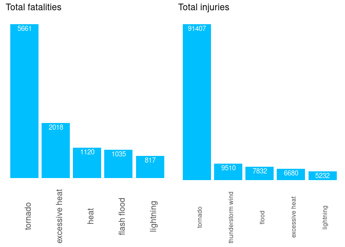

```r
# fatalities_sum_plot
sub <- arrange(damage_event, desc(fatalities_sum))[1:5,]
fatalities_sum_plot <- ggplot(data = sub,
                               aes(x = reorder(event, -fatalities_sum),
                                   y = fatalities_sum)) +
  geom_bar(stat='identity', fill = 'deepskyblue1') +
        theme_minimal() +
        theme(panel.grid.major = element_blank(),
              panel.grid.minor = element_blank(),
              axis.title.y = element_blank(),
              axis.ticks.y=element_blank(),
              axis.text.y=element_blank(),
              axis.text.x = element_text(size=12, angle=90),
              panel.background = element_blank()) +
        geom_text(aes(label = round(fatalities_sum, 1)),
                  color = 'white', vjust = +1.3, size = 3.5) +
        labs(x = NULL) +
        ggtitle('Total fatalities')

# injuries_sum_plot
sub <- arrange(damage_event, desc(injuries_sum))[1:5,]
injuries_sum_plot <- ggplot(data = sub,
                               aes(x = reorder(event, -injuries_sum),
                                   y = injuries_sum)) +
  geom_bar(stat='identity', fill = 'deepskyblue1') +
        theme_minimal() +
        theme(panel.grid.major = element_blank(),
              panel.grid.minor = element_blank(),
              axis.title.y = element_blank(),
              axis.ticks.y=element_blank(),
              axis.text.y=element_blank(),
              axis.text.x = element_text(size=9, angle=90),
              panel.background = element_blank()) +
        geom_text(aes(label = round(injuries_sum, 1)),
                  color = 'white', vjust = +1.3, size = 3.5) +
        labs(x = NULL) +
        ggtitle('Total injuries')

grid.arrange(fatalities_sum_plot, injuries_sum_plot, nrow = 1)
```

Floods are the greatest cause of property damage followed by hurricanes and tornadoes, although the most damaging on average per event are hurricanes and Storm Surge/Tide.

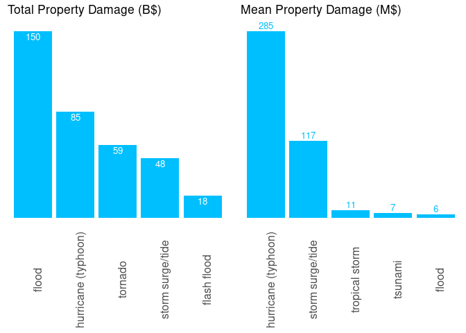

```r
# property_sum_plot
sub <- arrange(damage_event, desc(property_damage_sum))[1:5,]
property_sum_plot <- ggplot(data = sub,
                               aes(x = reorder(event, -property_damage_sum),
                                   y = property_damage_sum/1e9)) +
  geom_bar(stat='identity', fill = 'deepskyblue1') +
        theme_minimal() +
        theme(panel.grid.major = element_blank(),
              panel.grid.minor = element_blank(),
              axis.title.y = element_blank(),
              axis.ticks.y=element_blank(),
              axis.text.y=element_blank(),
              axis.text.x = element_text(size=12, angle=90),
              panel.background = element_blank()) +
        geom_text(aes(label = round(property_damage_sum/1e9, 0)),
                  color = 'white', vjust = +1.3, size = 3.5) +
        labs(x = NULL) +
        ggtitle('Total Property Damage (B$)')

# property_mean_plot
sub <- arrange(damage_event, desc(property_damage_mean))[1:5,]
property_mean_plot <- ggplot(data = sub,
                               aes(x = reorder(event, -property_damage_mean),
                                   y = property_damage_mean/1e6)) +
  geom_bar(stat='identity', fill = 'deepskyblue1') +
        theme_minimal() +
        theme(panel.grid.major = element_blank(),
              panel.grid.minor = element_blank(),
              axis.title.y = element_blank(),
              axis.ticks.y=element_blank(),
              axis.text.y=element_blank(),
              axis.text.x = element_text(size=12, angle=90),
              panel.background = element_blank()) +
        geom_text(aes(label = round(property_damage_mean/1e6, 0)),
                  color = 'deepskyblue1', vjust = -0.3, size = 3.5) +
        labs(x = NULL) +
        ggtitle('Mean Property Damage (M$)')
grid.arrange(property_sum_plot, property_mean_plot, nrow = 1)
```

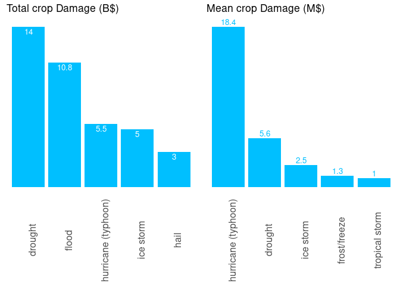

```r
# crop_sum_plot
sub <- arrange(damage_event, desc(crop_damage_sum))[1:5,]
crop_sum_plot <- ggplot(data = sub,
                               aes(x = reorder(event, -crop_damage_sum),
                                   y = crop_damage_sum/1e9)) +
  geom_bar(stat='identity', fill = 'deepskyblue1') +
        theme_minimal() +
        theme(panel.grid.major = element_blank(),
              panel.grid.minor = element_blank(),
              axis.title.y = element_blank(),
              axis.ticks.y=element_blank(),
              axis.text.y=element_blank(),
              axis.text.x = element_text(size=12, angle=90),
              panel.background = element_blank()) +
        geom_text(aes(label = round(crop_damage_sum/1e9, 1)),
                  color = 'white', vjust = +1.3, size = 3.5) +
        labs(x = NULL) +
        ggtitle('Total crop Damage (B$)')

# crop_mean_plot
sub <- arrange(damage_event, desc(crop_damage_mean))[1:5,]
crop_mean_plot <- ggplot(data = sub,
                               aes(x = reorder(event, -crop_damage_mean),
                                   y = crop_damage_mean/1e6)) +
  geom_bar(stat='identity', fill = 'deepskyblue1') +
        theme_minimal() +
        theme(panel.grid.major = element_blank(),
              panel.grid.minor = element_blank(),
              axis.title.y = element_blank(),
              axis.ticks.y=element_blank(),
              axis.text.y=element_blank(),
              axis.text.x = element_text(size=12, angle=90),
              panel.background = element_blank()) +
        geom_text(aes(label = round(crop_damage_mean/1e6, 1)),
                  color = 'deepskyblue1', vjust = -0.3, size = 3.5) +
        labs(x = NULL) +
        ggtitle('Mean crop Damage (M$)')
grid.arrange(crop_sum_plot, crop_mean_plot, nrow = 1)
```

[^1]: This article [“How To Handle Exponent Value of PROPDMGEXP and CROPDMGEXP”](https://rstudio-pubs-static.s3.amazonaws.com/58957_37b6723ee52b455990e149edde45e5b6.html) discusses this topic in more depth.